# BGobran_LiveSessionUnit11Assignment

#### 1 e – Make one point an outlier and see what that does to the seasonally adjusted data

##### In this case, I am choosing a point at middle to make an outlier

##### then I am making a graph showing the before and after seasonally adjusted result

```r
length(ukcars)
```

```
## [1] 113
```

```r
length(visitors)
```

```
## [1] 240
```

```r
length(hsales)
```

```
## [1] 275
```

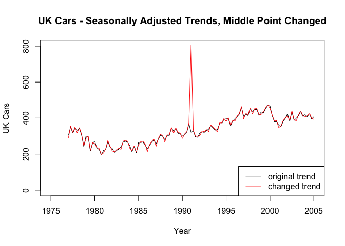

```r
ukcars[57] <- ukcars[57] + 500
visitors[120] <- visitors[120] + 500
hsales[138] <- hsales[138] + 500

fitukcars2 <- decompose(ukcars)
adjukcars2 <- seasadj(fitukcars2)

fitvisitors2 <- decompose(visitors)
adjvisitors2 <- seasadj(fitvisitors2)

fithsales2 <- decompose(hsales)
adjhsales2 <- seasadj(fithsales2)

plot(adjukcars, type="l", xlab = "Year", xlim=c(1975,2005), ylab = "UK Cars", ylim=c(0,800), main = "UK Cars - Seasonally Adjusted Trends, Middle Point Changed")
lines(adjukcars2, type="l", col="red")
legend("bottomright", lty=1, col=c("black","red"),c("original trend","changed trend"))
```

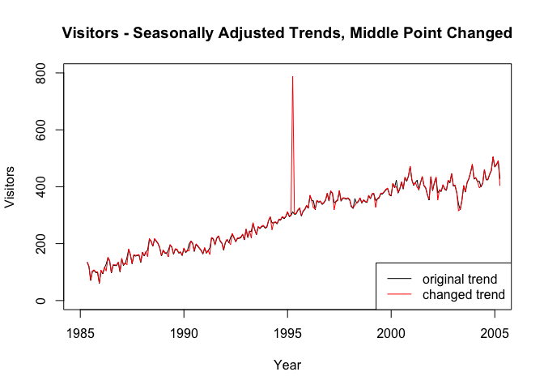

```r
plot(adjvisitors, type="l", xlab = "Year", xlim=c(1985,2005), ylab = "Visitors", ylim=c(0,800), main = "Visitors - Seasonally Adjusted Trends, Middle Point Changed")
lines(adjvisitors2, type="l", col="red")
legend("bottomright", lty=1, col=c("black","red"),c("original trend","changed trend"))
```

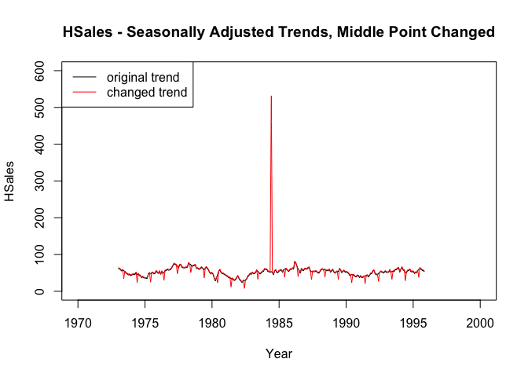

```r
plot(adjhsales, type="l", xlab = "Year", xlim=c(1970,2000), ylab = "HSales", ylim=c(0,600), main = "HSales - Seasonally Adjusted Trends, Middle Point Changed")
lines(adjhsales2, type="l", col="red")
legend("topleft", lty=1, col=c("black","red"),c("original trend","changed trend"))
```

##### The outlier seems to change these results for just that one point. I think that is a good thing.

#### 1 f – Does it make a difference if the outlier is at the middle or the end?

##### Here, create an outlier (10 points from the end) and make the comparison graphs again

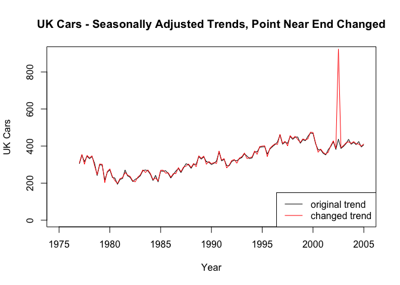

```r
ukcars[57] <- ukcars[57] - 500
visitors[120] <- visitors[120] - 500
hsales[138] <- hsales[138] - 500

ukcars[103] <- ukcars[103] + 500
visitors[230] <- visitors[230] + 500
hsales[265] <- hsales[265] + 500

fitukcars3 <- decompose(ukcars)
adjukcars3 <- seasadj(fitukcars3)

fitvisitors3 <- decompose(visitors)
adjvisitors3 <- seasadj(fitvisitors3)

fithsales3 <- decompose(hsales)
adjhsales3 <- seasadj(fithsales3)

plot(adjukcars, type="l", xlab = "Year", xlim=c(1975,2005), ylab = "UK Cars", ylim=c(0,900), main = "UK Cars - Seasonally Adjusted Trends, Point Near End Changed")
lines(adjukcars3, type="l", col="red")
legend("bottomright", lty=1, col=c("black","red"),c("original trend","changed trend"))
```

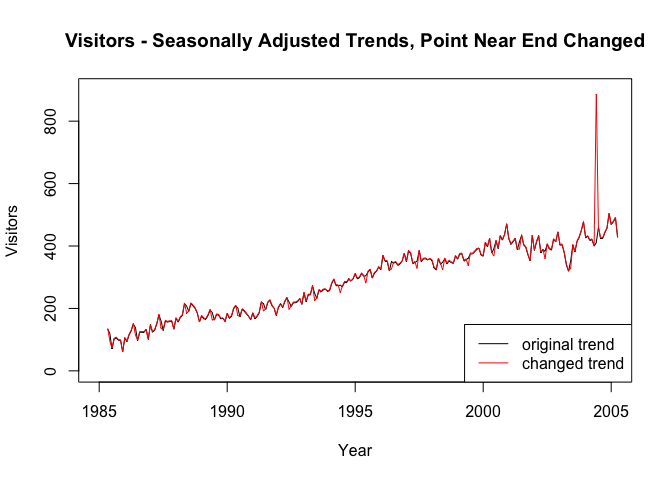

```r
plot(adjvisitors, type="l", xlab = "Year", xlim=c(1985,2005), ylab = "Visitors", ylim=c(0,900), main = "Visitors - Seasonally Adjusted Trends, Point Near End Changed")
lines(adjvisitors3, type="l", col="red")
legend("bottomright", lty=1, col=c("black","red"),c("original trend","changed trend"))
```

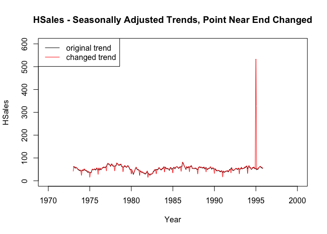

```r
plot(adjhsales, type="l", xlab = "Year", xlim=c(1970,2000), ylab = "HSales", ylim=c(0,600), main = "HSales - Seasonally Adjusted Trends, Point Near End Changed")
lines(adjhsales3, type="l", col="red")
legend("topleft", lty=1, col=c("black","red"),c("original trend","changed trend"))
```

##### Basically the spike effect is the same (a one-point change) regardless of where the outlier is in the data, the location just changes

#### 1 g – Perform an STL series decomposition

##### Remove the outlier, perform the decomposition, plot the STL results and the original data

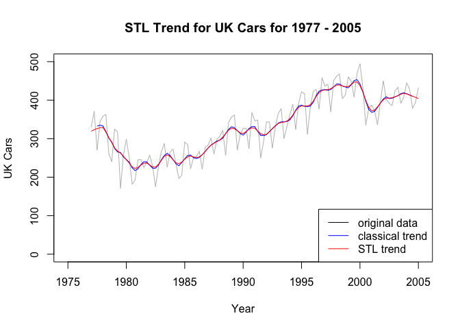

```r
ukcars[103] <- ukcars[103] - 500
visitors[230] <- visitors[230] - 500
hsales[265] <- hsales[265] - 500

stlfitukcars <- stl(ukcars, s.window=5)
stlfitvisitors <- stl(visitors, s.window=5)
stlfithsales <- stl(hsales, s.window=5)

plot(ukcars, type="l", xlab = "Year", xlim=c(1975,2005), ylab = "UK Cars", ylim=c(0,500), col="gray", main = "STL Trend for UK Cars for 1977 - 2005")
lines(fitukcars$trend, type="l", col="blue")
lines(stlfitukcars$time.series[,2], type="l", col="red")
legend("bottomright", lty=1, col=c("black","blue","red"),c("original data","classical trend", "STL trend"))
```

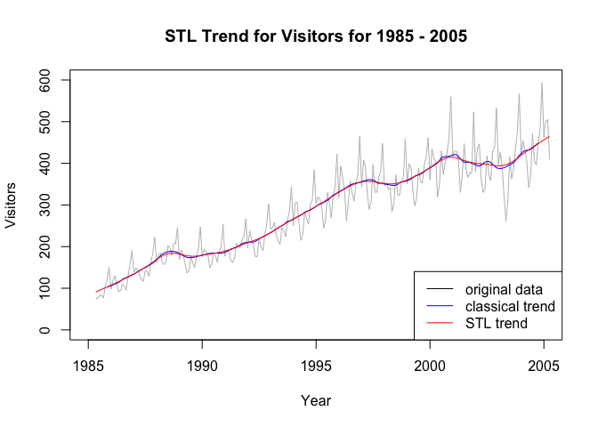

```r
plot(visitors, type="l", xlab = "Year", xlim=c(1985,2005), ylab = "Visitors", ylim=c(0,600), col="gray", main = "STL Trend for Visitors for 1985 - 2005")
lines(fitvisitors$trend, type="l", col="blue")
lines(stlfitvisitors$time.series[,2], type="l", col="red")
legend("bottomright", lty=1, col=c("black","blue","red"),c("original data","classical trend", "STL trend"))
```

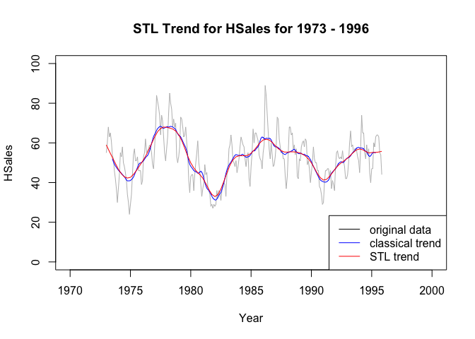

```r
plot(hsales, type="l", xlab = "Year", xlim=c(1970,2000), ylab = "HSales", ylim=c(0,100), col="gray", main = "STL Trend for HSales for 1973 - 1996")
lines(fithsales$trend, type="l", col="blue")
lines(stlfithsales$time.series[,2], type="l", col="red")
legend("bottomright", lty=1, col=c("black","blue","red"),c("original data","classical trend", "STL trend"))
```

##### The “trends” are effectively the same regardless of the decomposition method